# Conditional inference trees and random forests

Jason Grafmiller

July 2017

In this tutorial, I’ll go over the basics of how to use conditional inference trees and random forests to analyze language variation.

Classification and regression trees (CARTs) are similar in spirit to regression in that they are used to predict a response $Y$ from a set of predictors $X_1, X_2,...,X_n$. If the response is continuous we have a regression tree, if it is categorical, we have a classification tree. There are several packages in R for computing CARTs, e.g. `tree` and `rpart`, but in this tutorial we will be using a slightly different approach of **conditional inference trees** (ctrees) as implemented in the `party` and `partykit` packages.

In addition to individual ctrees, we will look at **random forest** methods, which use ensembles of many trees and random sampling processes to generate very accurate predictions as well as robust measures of individual predictors’ contribution to the model’s predictive capacity. I’ll explain more below.

**Let’s get started!**

Clear workspace:

```r
rm(list = ls(all = TRUE))
```

Before starting, make sure you have the following packages installed, and load them into your workspace.

```r
# install and load
library(plyr)
library(dplyr)
library(magrittr)
library(reshape2)

# for plotting
library(ggplot2)
library(grid)
library(gridExtra)

# for retrieving files from the web
library(RCurl)
```

For visualization, I use the `ggplot2` package, which is a powerful and popular package for creating professional looking graphics. However, the syntax can take a bit to get the hang of, but fortunately there are a number of excellent tutorials to help you get started. The documentation for all aspects of ggplot can be found [here](http://docs.ggplot2.org/current/index.html). I also highly recommend Winston Chang’s *Cookbook for R* page on [graphs with ggplot2](http://www.cookbook-r.com/Graphs/).

For the trees and forests, you’ll need to install the following packages **but do not load them yet**.

```r
install.packages(c("party", "partykit"))
# Note that the latter package builds off the former, however, some of the
# commands are slightly different.
```

### Example datasets

For the tutorial, we’ll use a couple datasets from two syntactic alternation phenomena.

To load the data, we’ll use the `RCurl` package to load the datasets directly from GitHub.

```r
gens <- readRDS(getURL("https://raw.github.com/jasongraf1/datasets/brown_genitives.rds"))
rels <- readRDS(getURL("https://raw.github.com/jasongraf1/datasets/brown_relatives.rds"))
```

The datasets are from two studies of syntactic alternations in English:

**Genitive alternation**

This dataset contains data from the Brown corpus used in Grafmiller (2014) as well as a complementary dataset from Frown.

1. the president’s assertion [*s*-genitive]
2. the contour of her face [*of*-genitive]

The English genitive alternation is known to be correlated with a number of features, including…

- the animacy of the possessor
- the length of the possessor and possessum
- the presence of a sibilant at the end of the possessor (*Bush’s prestige*)
- semantic relation between possessor and possessum (kinship, ownership, body-part, etc.)
- the ‘thematicity’ (text frequency) of the possessor
- the genre of the text (Newspaper, academic, fiction, etc.)

The goal of this study was to investigate the factors that co-determine (or at least correlate with) the choice of genitive variant.

**Relativizers**

This is the dataset of English relativizers originally compiled by Hinrichs et al. (2015) and also used in Grafmiller et al. (2016).

3. a doctrine *that* nobody either does or need hold
4. mistakes *which* others manage to avoid
5. the boundary conditions ∅ we impose

The choice among relative pronouns in English is known to be correlated with a number of features, including…

- the length of the relative clause
- the length of the antecedent NP (both this and the above are related to the complexity of the RC context)
- the part of speech of the antecedent
- the number of the antecedent
- the formality of the text
- prior use of a particular pronoun (‘structural persistence/priming’)
- the predictability of an upcoming RC, given the preceding material

Like the genitive case, the goal of these studies was to investigate the factors that co-determine/correlate with the choice of relativizer, particularly *that* vs. *which* vs. *ZERO* (or ∅)

# Conditional inference trees

Conditional inference trees are a non-parametric method (i.e. they do not make any assumptions about probability distributions of the variables) of classifying data based on a set of predictor variables.

Ctrees are related to traditional classification and regression trees, except that the method is designed explicitly to avoid known biases of such methods which tend to favor variables that have many possible splits or many missing values (Hothorn, Hornik & Zeileis 2006).

In more technical terms, `ctree()` derives splits using a [permutation significance test](https://en.wikipedia.org/wiki/Resampling_%28statistics%29#Permutation_tests) procedure “in which the distribution of the test statistic under the null hypothesis is obtained by calculating all possible values of the test statistic under rearrangements of the labels on the observed data points” (from wikipedia).

**An illustration**

Suppose we want to know to what extent speakers from Columbus, OH (part of the Midlands dialect region of American English) exhibit lower /æ/ vowels (as in *dad, fast*) than speakers from Cleveland, OH (part of the Northern Cities/Inland North dialect region).

We collect $N_b$ tokens of Columbusites’ /æ/s and $N_l$ tokens of Clevelanders’ /æ/s, from which we calculate the sample means for the height of the /æ/ vowels, represented by $\bar{x}_b$ and $\bar{x}_l$.

In our model, we have a predictor **city** with two values, ‘Columbus’ and ‘Cleveland’, and we want to test, at 5% significance level, whether our samples come from the same distribution. Our null hypothesis is that there is no difference in the height of Columbusites’ and Clevelanders’ pronunciation of /æ/.

- $H_0$: $\bar{x}_b - \bar{x}_l = 0$

The permutation test is designed to determine whether the observed difference between our sample means is large enough to reject the null hypothesis.

The test proceeds as follows.

1. The difference in the sample means is calculated: this is the observed value of the test statistic, $T_{obs}$.
2. Then the observations from the two cities are pooled.
3. We consider every possible way of dividing this pooled set of observations into two groups of $N_b$ and $N_l$ subsets. That is, we consider every permutation of the two cities). For each permutation, we calculate the difference in sample means. The set of these calculated differences is the exact distribution of possible differences under the null hypothesis that city does not matter.

The one-sided *p*-value of the test is the proportion of sampled permutations where the difference in means was greater than or equal to $T_{obs}$. If that value is less than .05, we reject the null hypothesis. The two-sided *p*-value of the test much the same, only it is the proportion of sampled permutations where the absolute difference was greater than or equal to $|T_{obs}|$.

Normally we’ll have a number of predictors that we want to consider as well, such as the age, gender, and level of education of the speakers, the type of segment preceding or following the vowel, and so on. The model calculates *p*-values using a permutation test for each of the predictors just like it did for the factor **city** above. The model then compares the *p*-values from all the factors (including city) and chooses the one with the smallest *p*-value, and makes the split according to that factor. The model uses *p*-values instead of the test statistics directly, because it could have predictors of different kinds, e.g. numeric and categorical, in which case the statistics (e.g. student’s $t$ or $\chi^2$) are not comparable.

This method is different from other classification tree packages like `rpart`, which selecting the split that maximizes an information measure, most commonly the [Gini coefficient](https://en.wikipedia.org/wiki/Gini_coefficient). These measures introduce bias in the selection procedure because they tend to select variables that have many possible splits or many missing values.

A nice thing about `ctree()` is that it can handle continuous, ordered, and categorical (binomial or multinomial) respose variables.

For more detailed discussion of the how conditional inference trees work, see Hothorn, Hornik & Zeileis (2006).

For this tutorial, we’ll use the `partykit` package, which is an extension of the earlier `party` package. It’s important to note that both packages use functions with the same names, most importantly `ctree()`, `cforest()`. If you load both packages into your workspace, you will see warnings about certain functions being masked. This means that the function from the first package loaded will no longer be called by default (you can call functions explicitly with `package::function()`). For this reason, it’s usually a good idea to load only one package at a time.

For ctrees, we’ll use `partykit` since it has better graphical implementation than the older `party`. This package has not been fully updated for random forests, so later we’ll use `party`.

```r
library(partykit)
```

## Simple conditional inference tree

Fit a ctree model and plot it. We’’l consider the effect of possessor animacy (as a binary variable) and final sibilant.

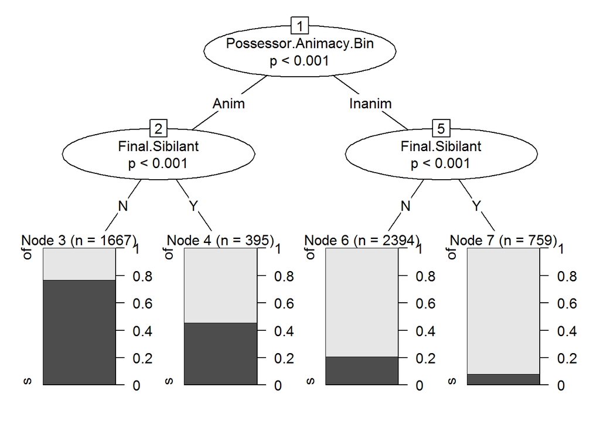

```r
gen.tree1 <- ctree(Type ~ Possessor.Animacy.Bin + Final.Sibilant,
  data = gens)
plot(gen.tree1)
```

We see from Node 1 that initially, the best split is between animate and inanimate possessors. Then, we look at the corresponding subsets and see that the presence of a final sibilant also has an effect.

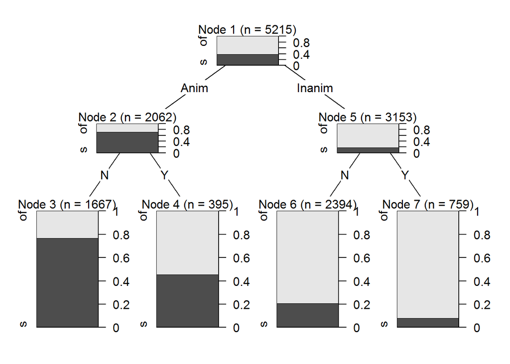

```r
plot(gen.tree1,
     inner_panel = partykit::node_barplot(gen.tree1))
```

We can generate predictions from the tree with the `predict()` function.

```r
ctree_predict <- predict(gen.tree1)

# proportion of observations correctly predicted by tree:
sum(gens$Type == ctree_predict)/nrow(gens)
```

```
[1] 0.7852349
```

This is a considerable improvement over the baseline, i.e. the percentage of observations we’d correctly predict if we simply guessed the more frequent response (*of*-genitive) everytime.

```r
max(table(gens$Type)/nrow(gens))
```

```
[1] 0.6139981
```

## Predict multiple responses

Let’s try to predict English relativizers with a simplified model, looking at only the object RCs.

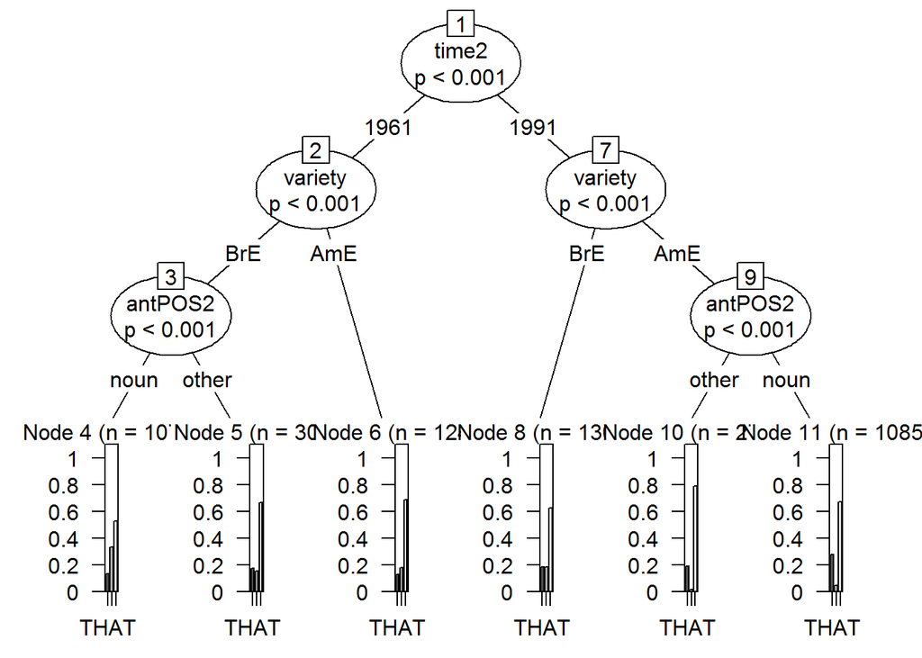

```r
objrels <- subset(rels, relFct == 'Obj') %>%
  droplevels
rc.tree1 <- ctree(rel ~ variety + time2 + antPOS2,
  data = objrels)
plot(rc.tree1)
```

## Pruning and tuning

Ctrees, like regression models, are also prone to overfitting the data. Consider the tree below.

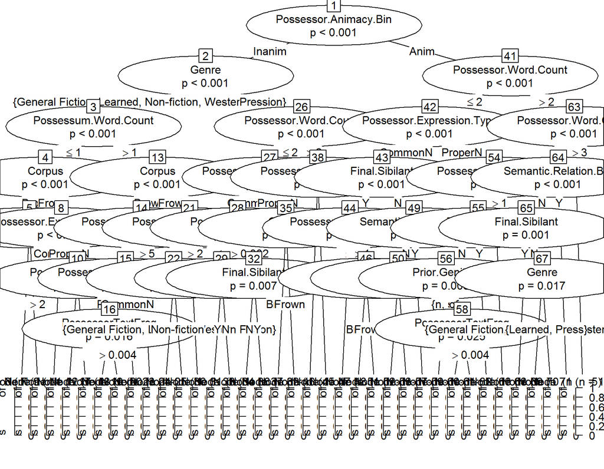

```r
gen.tree2 <- ctree(Type ~ Possessor.Animacy.Bin + Final.Sibilant + Possessor.Word.Count +
                     Semantic.Relation.Bin + Possessor.Expression.Type + Genre +
                     Corpus + Possessum.Word.Count + PossessorTextFreq +
                     PossessumTextFreq + Prior.Genitive,
                   data = gens)
plot(gen.tree2)
```

This tree is far too complicated to interpred in any useful way.

The tree will look for any and all possible splits in the data, regardless of whether those divisions are likely to replicated if we were to take different samples of genitive constructions. This is the problem of **overfitting**: our tree model is too finely tuned to our specific dataset, thus it does not represent a good model of genitive variation *in general*.

Adjusting for overfitting is often done post-hoc by “pruning” the tree, or it can be done prior to fitting the model by tuning the control settings of the function. Pruning is generally not something that is done with ctrees (indeed, the technique was designed partly to make pruning unnecessary). What we should do instead, is decide how to control the growth of the tree beforehand, in an unbiased way. There are a number of ways to do this.

```r
?partykit::ctree_control
```

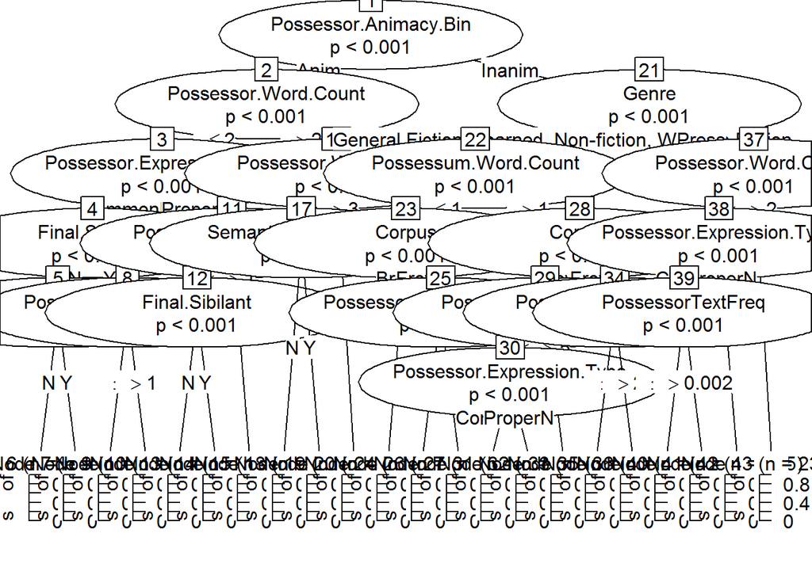

```r
gen.tree2b <- partykit::ctree(Type ~ Possessor.Animacy.Bin + Final.Sibilant +
    Possessor.Word.Count +
    Semantic.Relation.Bin + Possessor.Expression.Type + Genre +
    Corpus + Possessum.Word.Count + PossessorTextFreq +
    PossessumTextFreq + Prior.Genitive,
  data = gens,
  control = partykit::ctree_control(mincriterion = .999)) # now p < .001
plot(gen.tree2b)
```

The tree is simpler now, but still pretty unmanageable.

Another way to simplify the tree is to limit the maximum depth of the branching. The default is maxdepth = Inf, but you can tell it to stop splitting after a certain number of levels is reached.

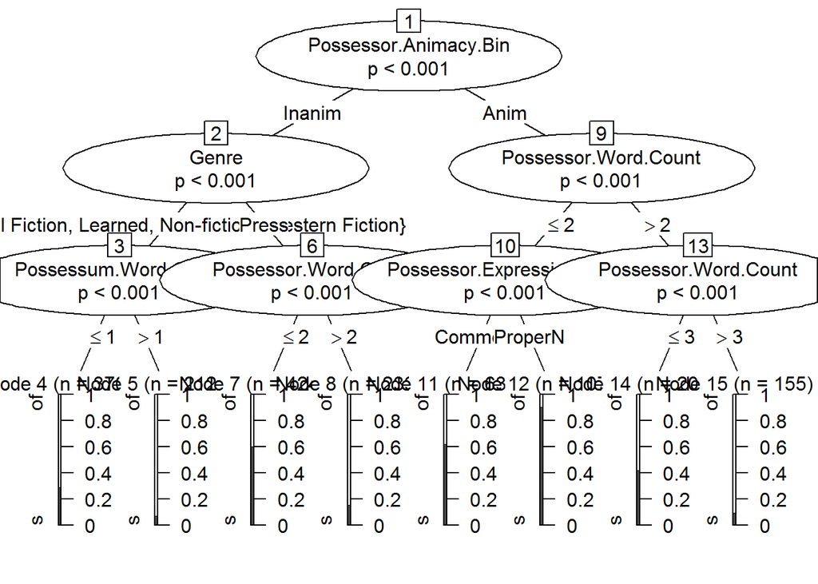

```r
gen.tree2c <- ctree(Type ~ Possessor.Animacy.Bin + Final.Sibilant +
    Possessor.Word.Count + Semantic.Relation.Bin + Possessor.Expression.Type +
    Genre + Corpus + Possessum.Word.Count + PossessorTextFreq +
    PossessumTextFreq + Prior.Genitive,
  data = gens,
  control = ctree_control(mincriterion = .999, maxdepth = 3))
plot(gen.tree2c)
```

This is better, but we may be losing some predictive power. The tree is likely to make less accurate predictions, but it is interpretable at least. Other options can be adjusted as needed/desired. See the documentation for `ctree` and `ctree_control` for how to do so.

## Graphical parameters

Large trees can be unwieldy to plot, and the partykit package offers ways to adjust the graphical settings of your trees to help with presentation.

```r
help("party-plot")
```

Basic global parameters are specified with a gpar() object

```r
?gpar
```

### Font size & face & family

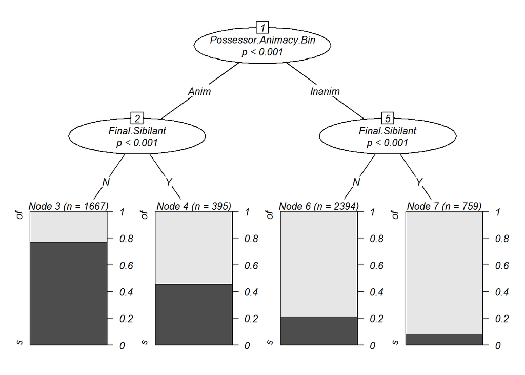

```r
# (cex is a multiplier)
plot(gen.tree1, gp = gpar(cex = .8, fontface = "italic"))
```

[figure not shown]

```r
plot(rc.tree1, gp = gpar(cex = .6, fontface = "italic"))
```

```r
# see also help(Hershey)
```

### Linetype & width (lex is a similar multiplier)

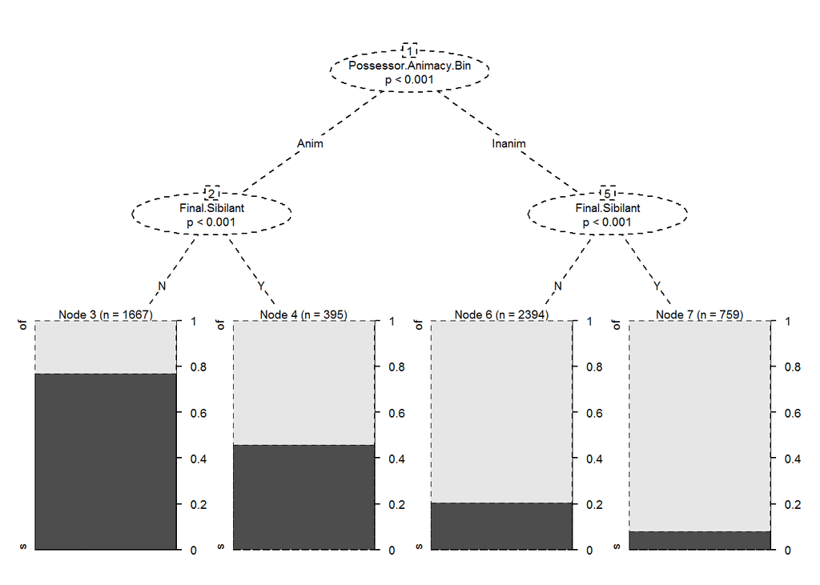

```r
plot(gen.tree1, gp = gpar(cex = .6, lty = 2)) # dashed lines
```

### Colors

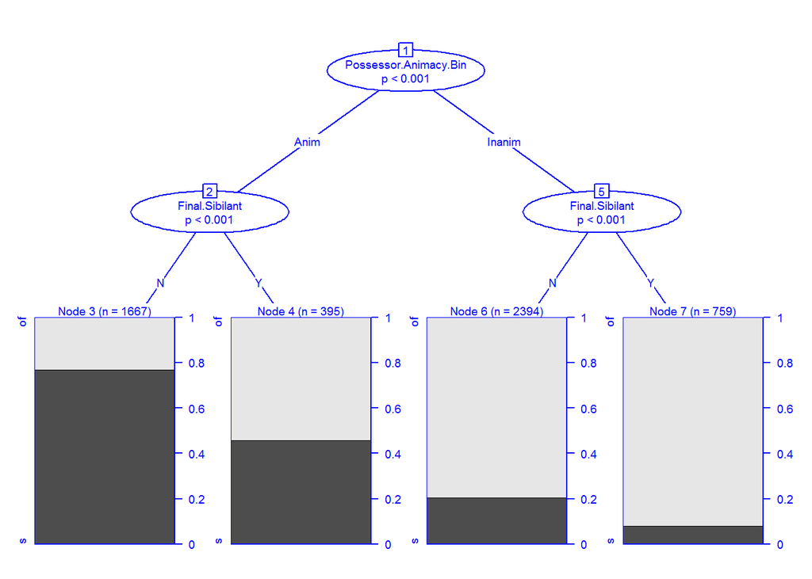

```r
plot(gen.tree1, gp = gpar(cex = .6, col = "blue"))
```

### Changing panels

The panels and edges themselves can be formatted as well (as we saw above)

```r
?panelfunctions
```

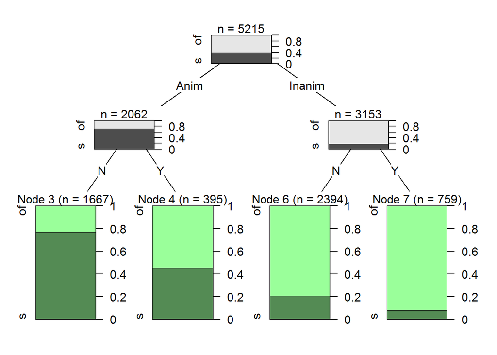

```r
library(partykit)
plot(gen.tree1,
  inner_panel = node_barplot, # create tree with inner panels as parplots
  ip_args = list(id = F), # remove IDs from inner panels
  tp_args = list(fill = c("palegreen4", "palegreen1"))
)
```

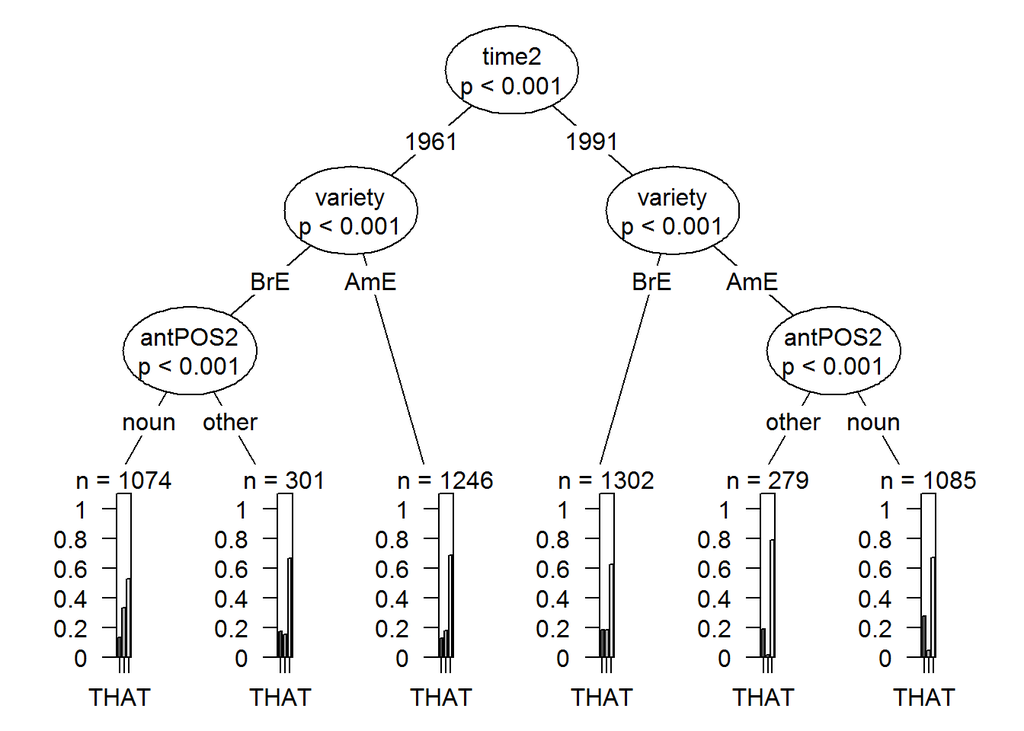

```r
plot(rc.tree1,
 gp = gpar(cex = .8),
 ip_args = list(id = F), # remove IDs and pvals from inner panels
 tp_args = list(id = F)
)
```

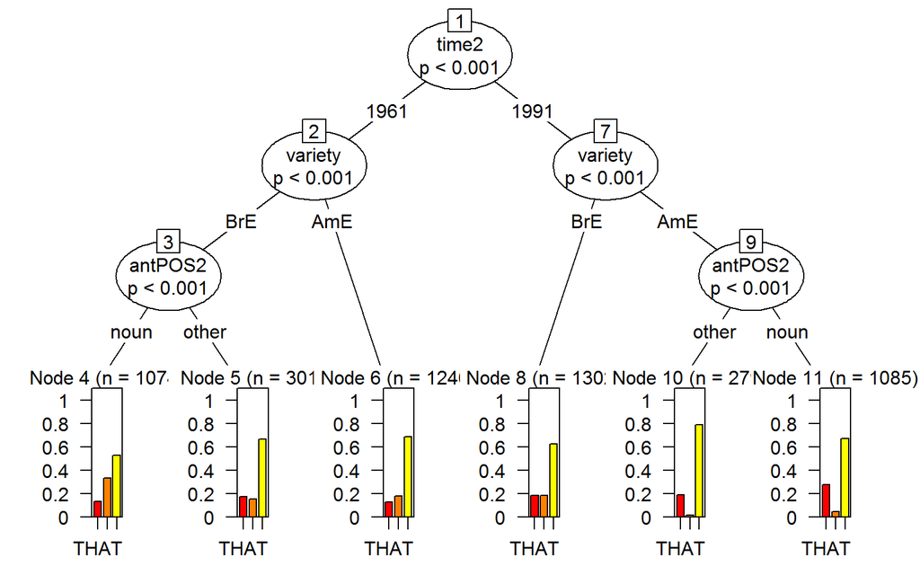

```r
# color bars
plot(rc.tree1,
   tp_args = list(fill = heat.colors(3))
)
```

# Conditional random forests

A problem with using single trees is that the tree structure is highly sensitive to particulars of your dataset, because each split (after the initial one) depends on previous ones.

We can illustrate this with a few random samples from the genitives dataset.

```r
set.seed(43214)
```

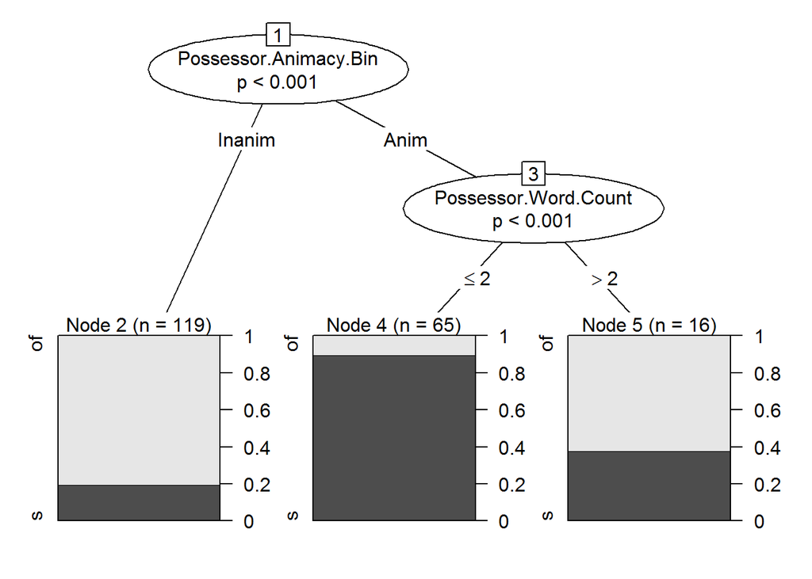

```r
plot(ctree(Type ~ Possessor.Animacy.Bin + Final.Sibilant +
    Possessor.Word.Count + Semantic.Relation.Bin + Possessor.Expression.Type +
    Genre + Corpus + Possessum.Word.Count + PossessorTextFreq +
    PossessumTextFreq + Prior.Genitive,
  data = gens[sample(1:nrow(gens), 200, replace = F),],
  control = ctree_control(mincriterion = .99, maxdepth = 4)),
  gp = gpar(cex = .8))
```

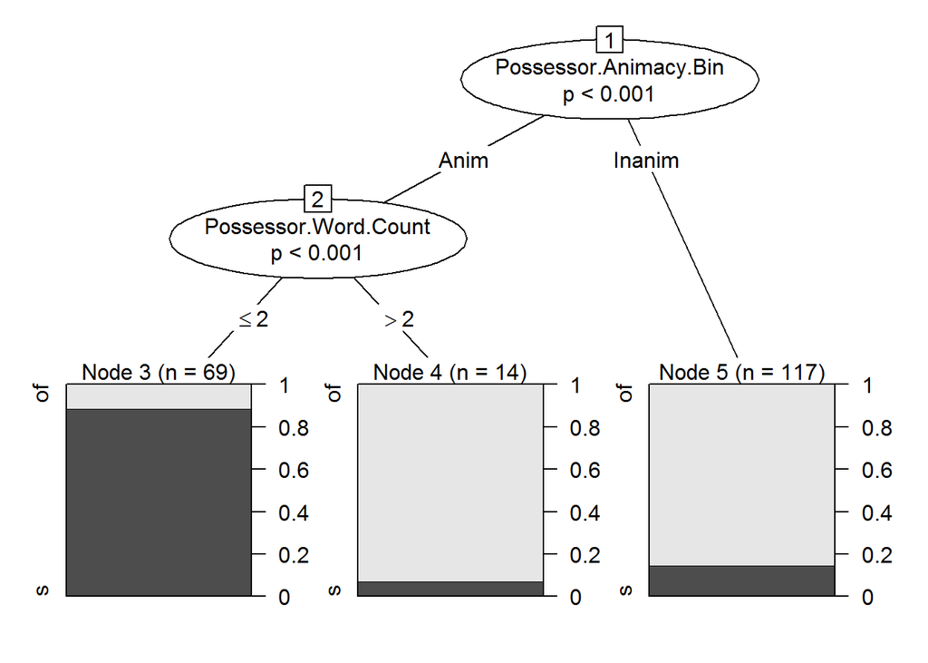

```r
plot(ctree(Type ~ Possessor.Animacy.Bin + Final.Sibilant +
    Possessor.Word.Count + Semantic.Relation.Bin + Possessor.Expression.Type +
    Genre + Corpus + Possessum.Word.Count + PossessorTextFreq +
    PossessumTextFreq + Prior.Genitive,
  data = gens[sample(1:nrow(gens), 200, replace = F),],
  control = ctree_control(mincriterion = .99, maxdepth = 4)),
  gp = gpar(cex = .8))
```

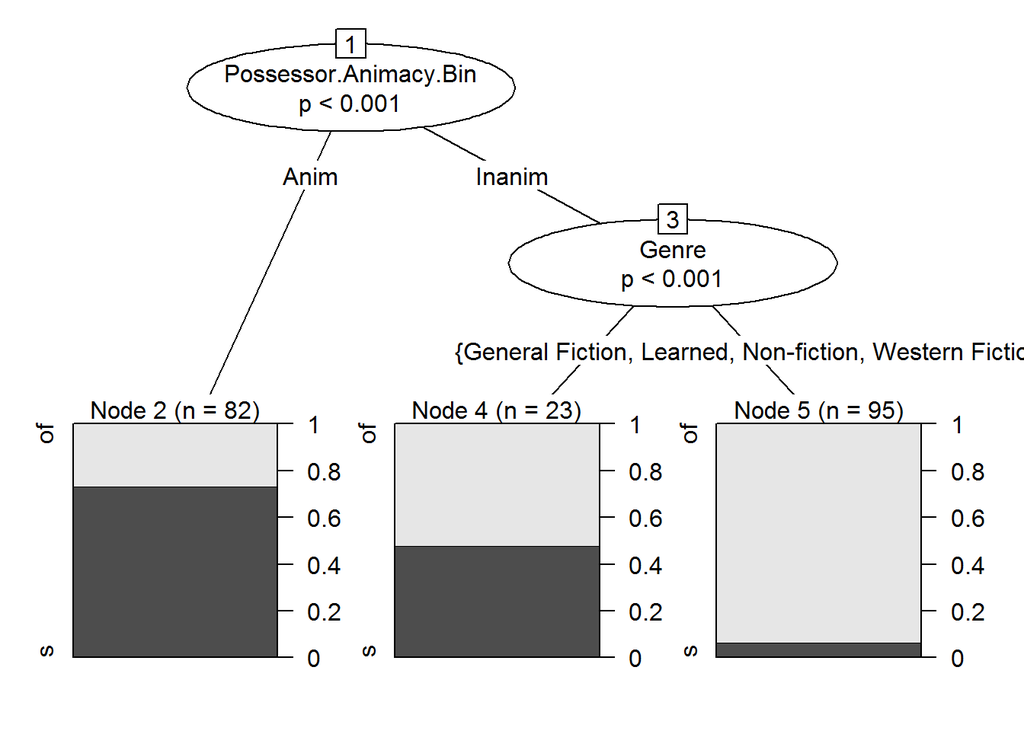

```r
plot(ctree(Type ~ Possessor.Animacy.Bin + Final.Sibilant +
    Possessor.Word.Count + Semantic.Relation.Bin + Possessor.Expression.Type +
    Genre + Corpus + Possessum.Word.Count + PossessorTextFreq +
    PossessumTextFreq + Prior.Genitive,
  data = gens[sample(1:nrow(gens), 200, replace = F),],
  control = ctree_control(mincriterion = .99, maxdepth = 4)),
  gp = gpar(cex = .8))
```

Conditional Random Forests offer a solution to this problem. Instead of using a single tree, the method uses a forest of trees, each of which is grown on random subsamples of the data based on a randomly selected subset of predictors. This results in a healthy mix of very diverse trees, where all predictors have a greater chance of being included in the model even when a stronger competitor is not.

Use the `party` package for random forests now, since random forests have not been fully implemented in `partykit`.

```r
detach("package:partykit", unload = TRUE)
library(party)
```

## Setting controls

In addition to the tunings for the individual trees, (“teststat”, “mincriterion”, etc.) we need to specify two important control parameters—`mtry` and `ntree`. You can see what these do with `?cforest_control`:

- `mtry`: number of input variables randomly sampled as candidates at each node for random forest like algorithms. Bagging, as special case of a random forest without random input variable sampling, can be performed by setting mtry either equal to NULL or manually equal to the number of input variables.
- `ntree`: number of trees to grow in a forest.

Further details are provided in the details section.

> The mtry argument regulates a random selection of mtry input variables in each node. Note that here mtry is fixed to the value 5 by default for merely technical reasons, while in randomForest the default values for classification and regression vary with the number of input variables. Make sure that mtry is defined properly before using cforest. … The number of trees ntree can be increased for large numbers of input variables.

As a rule of thumb, Brieman recommends setting `mtry` equal to $\sqrt{k}$ for a model with $k$ predictors. The number of trees is something that is a bit harder to determine. Generally speaking, the smaller your dataset, and the larger the number of predictors, the more trees you should grow. There are methods for exploring just what the optimal setting might be, but these can be very time consuming.

Once we’ve set our control parameters, we can fit our tree with `cforest()`.

```r
ctrl <- party::cforest_control(mtry = 3, ntree = 500)

gen.forest1 <- party::cforest(Type ~ Possessor.Animacy.Bin + Final.Sibilant +
    Possessor.Word.Count + Genre + Corpus,
  data = gens, controls = ctrl)
```

The output of the `cforest()` function is not very informative.

```r
summary(gen.forest1)
```

```
      Length        Class         Mode
           1 RandomForest           S4
```

Note also that random forests are very large objects (at least > 100Mb) so they can be slow to load and can bog down your system.

## Generating predictions

The `treeresponse()` function provides predicted probability of each response for each observation.

```r
gen.forest1.preds <- treeresponse(gen.forest1)
```

We’ll focus only on the predicted probability of the *s*-genitive here. We can use the `somers2()` function in the `Hmisc` to obtain the index of concordance, C, which is a measure of how well the model predicts the data. Values above .8 indicate a good fit to the data.

```r
gen.preds1 <- sapply(gen.forest1.preds, FUN = function(v) return(v[2]))

Hmisc::somers2(gen.preds1, as.numeric(gens$Type) - 1)
```

```
           C          Dxy            n      Missing
   0.9007643    0.8015287 5215.0000000    0.0000000
```

## Permutation variable importance

Unlike single ctrees or regression models, reading partial effects off a random forest model is not easy because a single predictor can show up in many different (non-nested) trees with different co-varying predictors (and interactions). So random forests don’t give you direct effect size measures comparable to regression coefficients, nor to they conduct null hypothesis significance tests for your predictors, as with regression models.

But, random forests and ensemble methods make up for this shortcoming in being a great tool for model and predictor selection. Due to the random sampling and permutation processes, they are very good at determining the independent contributions of individual predictors to the model even when those predictors are highly correlated with one another (as is often the case). And since they rely on many, many ctrees, they can model non-linearities quite naturally. All this results in us gaining much more information about how each predictor behaves with respect to the data.

To assess the contribution of each predictor, the random forest model computes a **permutation variable importance** score.

Permutation variable importance works as follows:

- Take one predictor and randomly shuffle the values of that predictor to break the association between the response and predictor
- Calculate the difference in model accuracy before and after shuffling.
- If the predictor does not have a meaningful relationship with the response, shuffling its values should produce very little change in model accuracy. On the other hand, if the predictor was strongly associated with the response, permutation should create a large drop in accuracy.
- Do this for every predictor in the model, and rank them according to their importance.

Permutation variable importance covers the individual impact of each predictor in the random forest model, including its impact in interactions (which is much harder to assess in regression models).

To illustrate, consider the substantial effect of possessor animacy on genitive choice.

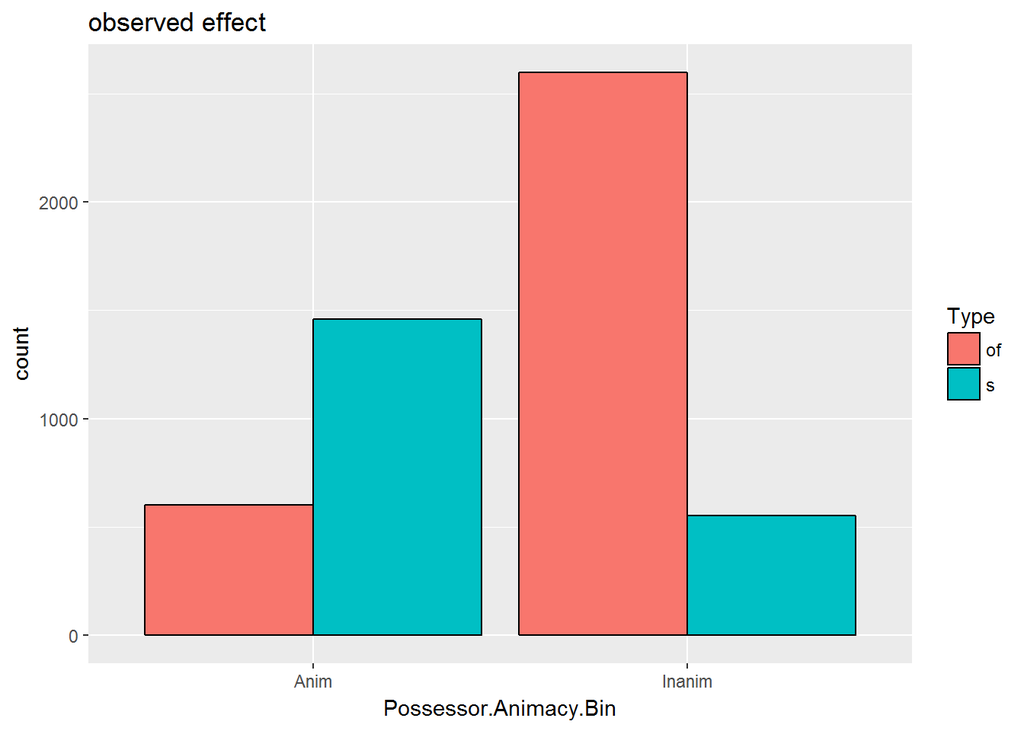

```r
ggplot(gens) +
  geom_bar(aes(Possessor.Animacy.Bin, fill = Type),
    position = 'dodge', color = 'black') +
  labs(title = 'observed effect')
```

We can do a quick `chisq.test` and see that this effect in our data is very unlikely to have occurred if there were no relationship between possessor animacy and genitive type.

```r
chisq.test(table(gens$Possessor.Animacy.Bin, gens$Type))
```

```
    Pearson's Chi-squared test with Yates' continuity correction

data:  table(gens$Possessor.Animacy.Bin, gens$Type)
X-squared = 1490.2, df = 1, p-value < 2.2e-16
```

Now suppose we reshuffle the values of `Possessor.Animacy.Bin` (while leaving the values of Type intact)…

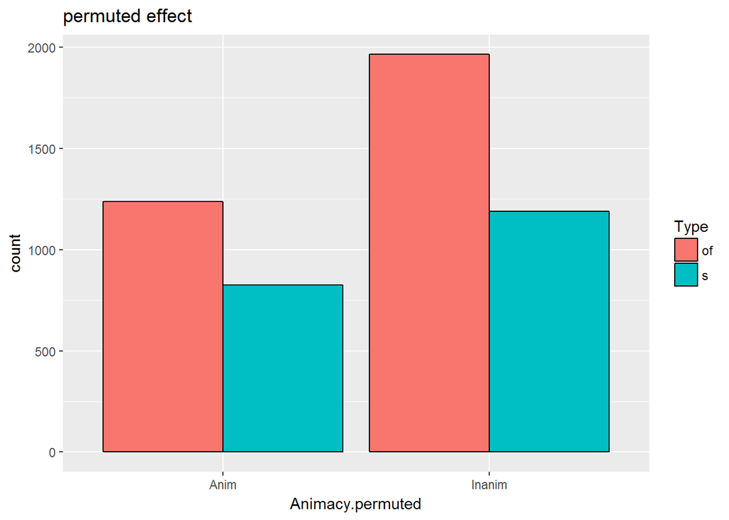

```r
# randomly resample from the original column and assign it to a new one
gens$Animacy.permuted <- sample(gens$Possessor.Animacy.Bin)

# now regenerate the above plot with the new column
ggplot(gens) +
  geom_bar(aes(Animacy.permuted, fill = Type),
    position = 'dodge', color = 'black') +
  labs(title = 'permuted effect')
```

```r
table(gens$Possessor.Animacy.Bin)
```

```
  Anim Inanim
  2062   3153
```

```r
table(gens$Animacy.permuted)
```

```
  Anim Inanim
  2062   3153
```

Doublecheck the values…

```r
head(gens[, c('Type', 'Possessor.Animacy.Bin', 'Animacy.permuted')], 15)
```

```
   Type Possessor.Animacy.Bin Animacy.permuted
1    of                Inanim           Inanim
2     s                  Anim           Inanim
3     s                  Anim           Inanim
4     s                  Anim           Inanim
5    of                Inanim           Inanim
6    of                Inanim           Inanim
7     s                  Anim             Anim
8     s                  Anim           Inanim
9     s                  Anim             Anim
10    s                  Anim           Inanim
11    s                Inanim           Inanim
12    s                  Anim           Inanim
13    s                Inanim             Anim
14    s                  Anim           Inanim
15    s                Inanim             Anim
```

```r
chisq.test(table(gens$Possessor.Animacy.Bin, gens$Type))
```

```
    Pearson's Chi-squared test with Yates' continuity correction

data:  table(gens$Possessor.Animacy.Bin, gens$Type)
X-squared = 1490.2, df = 1, p-value < 2.2e-16
```

The idea is to do this for every predictor in every tree in the forest. This process can take some time…

```r
system.time( # track the time it takes to run
  gen.pvi <- varimp(gen.forest1, conditional = T))
```

```
   user  system elapsed
 138.75    0.52  139.64
```

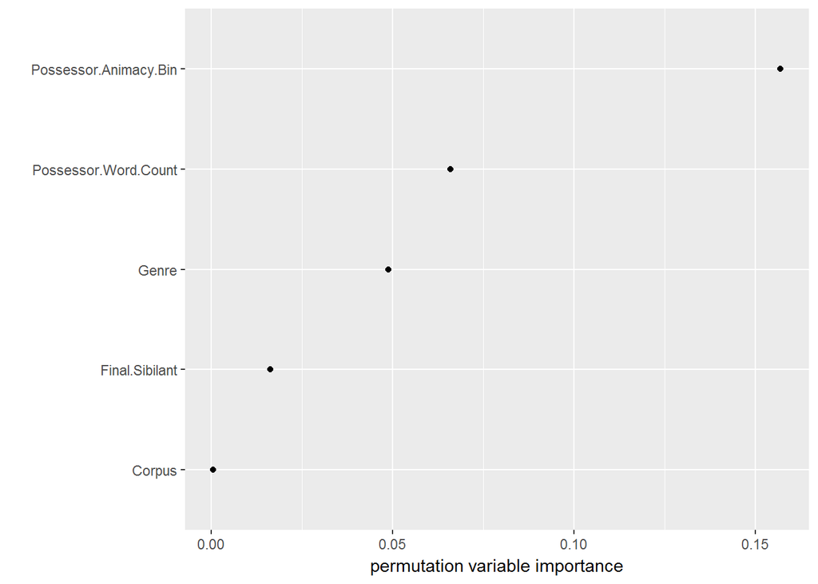

```r
gen.pvi <- data.frame(sort(gen.pvi))
names(gen.pvi) <- "varimp"
gen.pvi$pred = factor(rownames(gen.pvi), levels = rownames(gen.pvi))

gensF.plot1 <- ggplot(gen.pvi, aes(pred, varimp)) + coord_flip() +
  geom_point() +
  labs(x = "", y = "permutation variable importance")
gensF.plot1
```

By chance, the random reordering of values sometimes results in a configuration that affords a slightly *better* model. This may arise when the values of an irrelevant predictor are reshuffled. In other words, the random reshuffling created a new version of the predictor that is actually *more* strongly associated with the outcome than the original predictor. This has the effect of creating a negative variable importance score.

By mirroring the minimal score to the right of zero, we obtain an interval that characterizes irrelevant predictors. Variables can be considered informative and important if their variable importance value lies above (to the right) this region. In some cases, this may include all predictors.

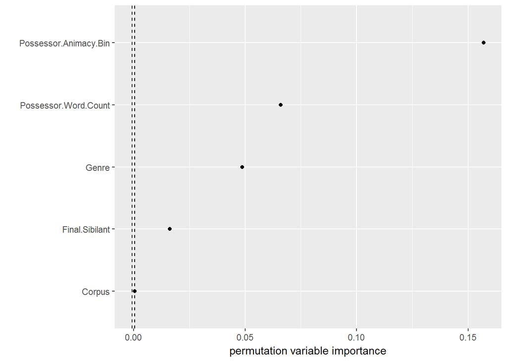

```r
m <- abs(min(gen.pvi$varimp))
gensF.plot1 + geom_hline(yintercept = c(-m, m), linetype = "dashed")
```

It’s important to remember that these variable importance scores should only be interpreted relative to each other as a ranking of the model’s predictors. The absolute values of the scores should not be interpreted or compared across studies (see Strobl, Malley & Tutz 2009:336).

Since the forest are random, they should also be verified by fitting multiple models with different random seeds and ntree numbers.

```r
set.seed(20)

ctrl <- party::cforest_control(mtry = 3, ntree = 800)

gen.forest1b <- party::cforest(Type ~ Possessor.Animacy.Bin + Final.Sibilant +
                                 Possessor.Word.Count + Genre,
                               data = gens, controls = ctrl)

# predictions
gen.forest1b.preds <- treeresponse(gen.forest1b)

# We'll focus only on the s-gens
gen.preds1b <- sapply(gen.forest1.preds, FUN = function(v) return(v[1]))

somers2(gen.preds1b, as.numeric(gens$Type) - 1)
```

```
            C           Dxy             n       Missing
   0.09923567   -0.80152866 5215.00000000    0.00000000
```

```r
somers2(gen.preds1, as.numeric(gens$Type) - 1)
```

```
           C          Dxy            n      Missing
   0.9007643    0.8015287 5215.0000000    0.0000000
```

```r
# Variable importance
system.time( # track the time it takes to run
  gen.pvi2 <- varimp(gen.forest1b, conditional = T)
)
```

```
   user  system elapsed
 166.28    0.32  167.97
```

[figure not shown]

```r
gen.pvi2 <- data.frame(sort(gen.pvi2))
names(gen.pvi2) <- "varimp"
gen.pvi2$pred = factor(rownames(gen.pvi2), levels = rownames(gen.pvi2))

gensF.plot1b <- ggplot(gen.pvi2, aes(pred, varimp)) + coord_flip() +
  geom_point() +
  labs(x = "", y = "permutation variable importance")

grid.arrange(gensF.plot1, gensF.plot1b)
```

## Partial effects

As I mentioned above, reading effects of individual predictors off a random forest model is not easy because a forest—as the name implies—can contain many hundreds or even thousands of potentially very different trees. There is therefore no method for computing *p*-values for individual predictors or their interactions.

There is however a nice package that can quickly calculate partial dependence plots of the marginal effects of (a set of) predictors on the response with the average effect of all the other predictors.

```r
library(edarf)
```

```r
pd1 <- partial_dependence(gen.forest1, vars = 'Genre', n = c(5, 20))
pd1
```

```
            Genre        of         s
1 General Fiction 0.5765055 0.4234945
2         Learned 0.5824671 0.4175329
3     Non-fiction 0.5539689 0.4460311
4           Press 0.3963880 0.6036120
5 Western Fiction 0.5635801 0.4364199
```

The package has its own plot function `plot_pd()`, but I’ve found it to be a bit buggy, and so I perfer to do things my own way.

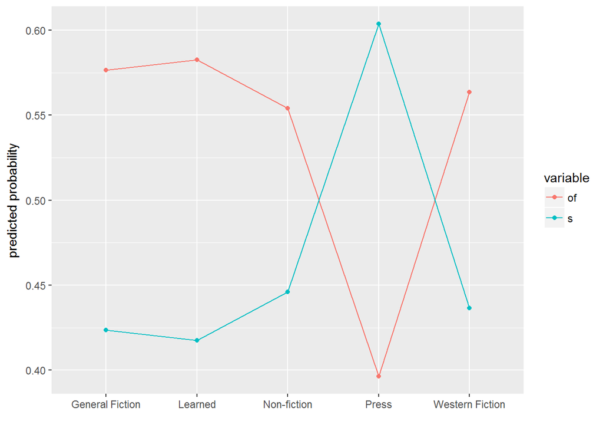

```r
pd1a <- reshape2::melt(pd1, id.vars = 'Genre')
ggplot(pd1a, aes(x = Genre, y = value, group = variable)) +
  geom_line(aes(color = variable)) +
  geom_point(aes(color = variable)) +
  labs(x = '', y = 'predicted probability')
```

We can do the same with all the “main effects” simultaneously with a little knowledge of custom functions and `plyr`. First we create a vector of all the predictors in our formula

```r
f <- Type ~ Possessor.Animacy.Bin + Final.Sibilant +
    Possessor.Word.Count + Genre
# leave out the response
vars <- all.vars(f)[-1]
```

Now we define a function that will calculate the partial dependence for a given predictor and generate a ggplot object for it. For the `n` argument in `partial_dependence()`, we’ll have the function find the appropriate number of levels for factor predictors, or use 10 if the predictor is numeric.

```r
fn <- function(x) {
  nlevs <- ifelse(is.factor(gens[,x]), nlevels(gens[,x]), 10)
  pd <- partial_dependence(gen.forest1, vars = x, n = c(nlevs, 100))
  p <- ggplot(melt(pd, id.vars = x),
    aes_string(x = x, y = 'value', group = 'variable')) +
    geom_line(aes(color = variable)) +
    geom_point(aes(color = variable)) +
    labs(x = x, y = 'predicted probability')
}
```

Next we just loop through the list of predictors and apply our function using `llply()`. This function takes a vector of items, applies a function, and returns the outputs of the function in a list.

```r
partials <- llply(vars, .fun = fn)
```

Finally, we’ll arrange these all in a single plot grid.

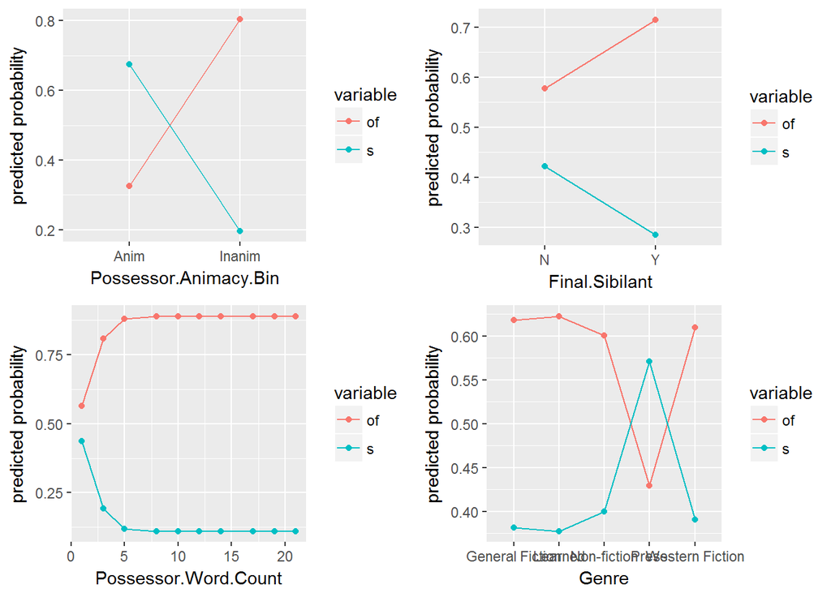

```r
do.call('grid.arrange', c(partials, ncol = 2))
```

Alternatively, you could plot each predictor individually with `partials[[i]]` where `i` is either the name of the predictor or the number of its place in the list.

# Summary

Advantages of conditional inference trees:

- capture well nonlinear effects and complex interactions
- computationally fairly simple
- provide intuitive visualizations that are a good way to explore patterns in your data

Disadvantages of conditional inference trees:

- sensitive to particularities of your data
- large trees can be difficult to interpret
- generally perform worse than other methods, e.g. regression

Advantages of random forests:

- can handle small datasets with relatively large sets of predictors
- robust against problems of collinearity
- deals well with nonlinear effects and high-order interactions
- are more accurate than single trees and regression models

Disadvantages of random forests:

- long computing time (especially for variable imortance)
- do not provide traditional measures of effect size and direction

# References

Bernaisch, Tobias, Stefan Th. Gries & Joybrato Mukherjee. 2014. The dative alternation in South Asian English(Es): Modelling predictors and predicting prototypes. *English World-Wide* 35. 7–31.

Breiman, Leo. 2001. Random Forests. *Machine Learning* 41. 5–32.

Grafmiller, Jason. 2014. Variation in English Genitives across Modality and Genres. *English Language and Linguistics* 18(03). 471–496. doi:10.1017/S1360674314000136 (4 December, 2014).

Grafmiller, Jason, Benedikt Szmrecsanyi & Lars Hinrichs. 2016. Restricting the restrictive relativizer. *Corpus Linguistics and Linguistic Theory* 0(0). doi:10.1515/cllt-2016-0015 (5 July, 2017).

Hinrichs, Lars, Benedikt Szmrecsanyi & Axel Bohmann. 2015. *Which*-hunting and the Standard English relative clause. *Language* 91(4). 806–836.

Hothorn, Torsten, Kurt Hornik & Achim Zeileis. 2006. Unbiased recursive partitioning: A conditional inference framework. *Journal of Computational and Graphical Statistics* 15(3). 651–674. doi:10.1198/106186006X133933 (25 November, 2014).

Strobl, Carolin, James Malley & Gerhard Tutz. 2009. An introduction to recursive partitioning: Rationale, application, and characteristics of classification and regression trees, bagging, and random forests. *Psychological Methods* 14(4). 323–348. doi:10.1037/a0016973.

Szmrecsanyi, Benedikt, Jason Grafmiller, Benedikt Heller & Melanie Röthlisberger. 2016. Around the world in three alternations: Modeling syntactic variation in varieties of English. *English World-Wide* 37(2). 109–137. doi:10.1075/eww.37.2.01szm (27 June, 2017).